# 12_ave_more

## 12_ave_more

#### Question

1. The continuous random variable $X$ follows the distribution shown by the density curve and spinner below. It has a mean of $\mu=9.96$ and standard deviation of $\sigma=1.75$.

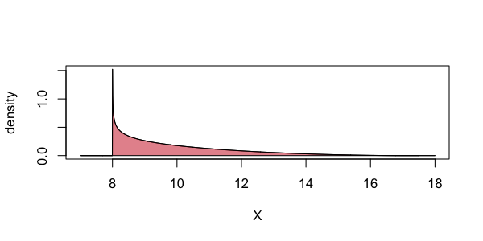

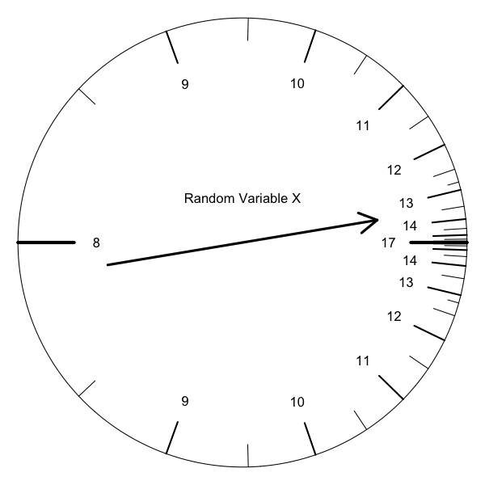

   That spinner ($X$) will be fairly spun 882 times, and the **sample mean** ($\bar{X}$) of the spins will be recorded. Determine the probability that the random sample mean is more than 9.99.
   $$P\left(\bar{X}>9.99\right) ~=~ \,?$$

   (Even though single spins are **not** normally distributed, the random means will be normally distributed. See [central limit theorem](https://en.wikipedia.org/wiki/Central_limit_theorem).)

#### Question

2. The continuous random variable $X$ follows the distribution shown by the density curve and spinner below. It has a mean of $\mu=65.66$ and standard deviation of $\sigma=6.67$.

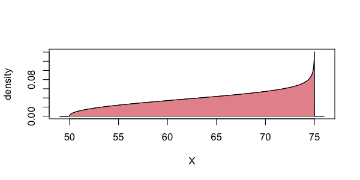

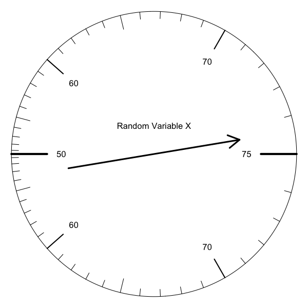

   That spinner ($X$) will be fairly spun 378 times, and the **sample mean** ($\bar{X}$) of the spins will be recorded. Determine the probability that the random sample mean is more than 65.63.
   $$P\left(\bar{X}>65.63\right) ~=~ \,?$$

   (Even though single spins are **not** normally distributed, the random means will be normally distributed. See [central limit theorem](https://en.wikipedia.org/wiki/Central_limit_theorem).)

#### Question

3. The continuous random variable $X$ follows the distribution shown by the density curve and spinner below. It has a mean of $\mu=60.18$ and standard deviation of $\sigma=2.26$.

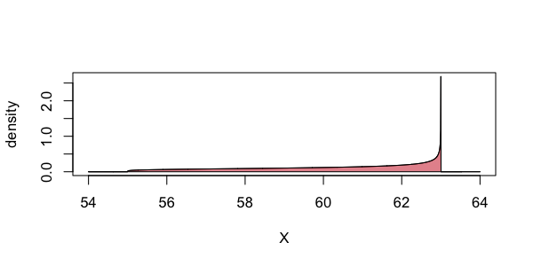

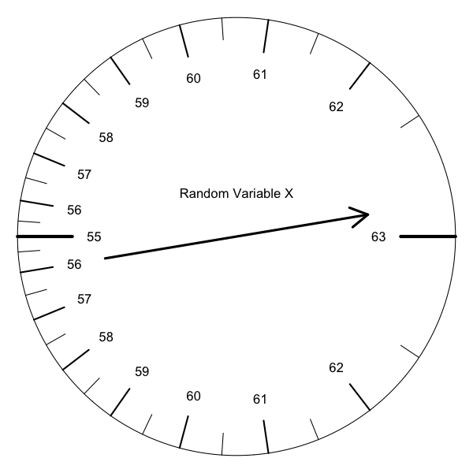

   That spinner ($X$) will be fairly spun 672 times, and the **sample mean** ($\bar{X}$) of the spins will be recorded. Determine the probability that the random sample mean is more than 60.34.
   $$P\left(\bar{X}>60.34\right) ~=~ \,?$$

   (Even though single spins are **not** normally distributed, the random means will be normally distributed. See [central limit theorem](https://en.wikipedia.org/wiki/Central_limit_theorem).)

#### Question

4. The continuous random variable $X$ follows the distribution shown by the density curve and spinner below. It has a mean of $\mu=66.67$ and standard deviation of $\sigma=16.85$.

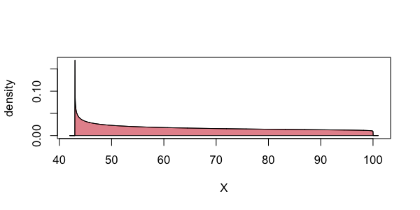

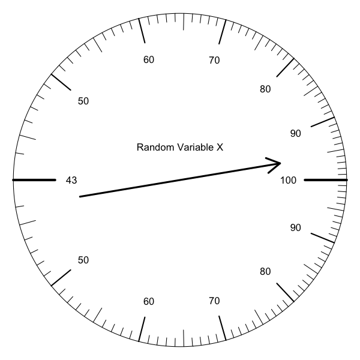

   That spinner ($X$) will be fairly spun 677 times, and the **sample mean** ($\bar{X}$) of the spins will be recorded. Determine the probability that the random sample mean is more than 66.42.
   $$P\left(\bar{X}>66.42\right) ~=~ \,?$$

   (Even though single spins are **not** normally distributed, the random means will be normally distributed. See [central limit theorem](https://en.wikipedia.org/wiki/Central_limit_theorem).)

#### Question

5. The continuous random variable $X$ follows the distribution shown by the density curve and spinner below. It has a mean of $\mu=60.88$ and standard deviation of $\sigma=8.74$.

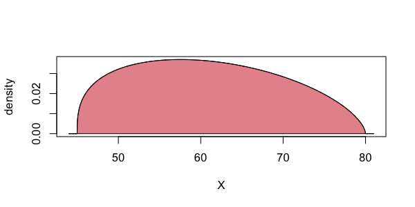

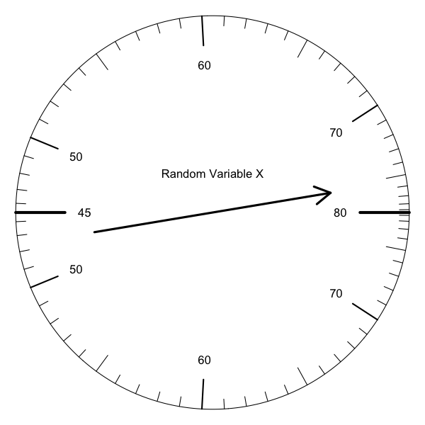

   That spinner ($X$) will be fairly spun 579 times, and the **sample mean** ($\bar{X}$) of the spins will be recorded. Determine the probability that the random sample mean is more than 61.19.
   $$P\left(\bar{X}>61.19\right) ~=~ \,?$$

   (Even though single spins are **not** normally distributed, the random means will be normally distributed. See [central limit theorem](https://en.wikipedia.org/wiki/Central_limit_theorem).)

#### Question

6. The continuous random variable $X$ follows the distribution shown by the density curve and spinner below. It has a mean of $\mu=24.73$ and standard deviation of $\sigma=12.44$.

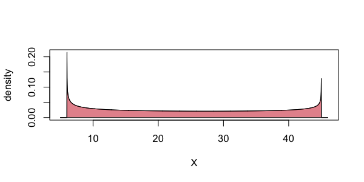

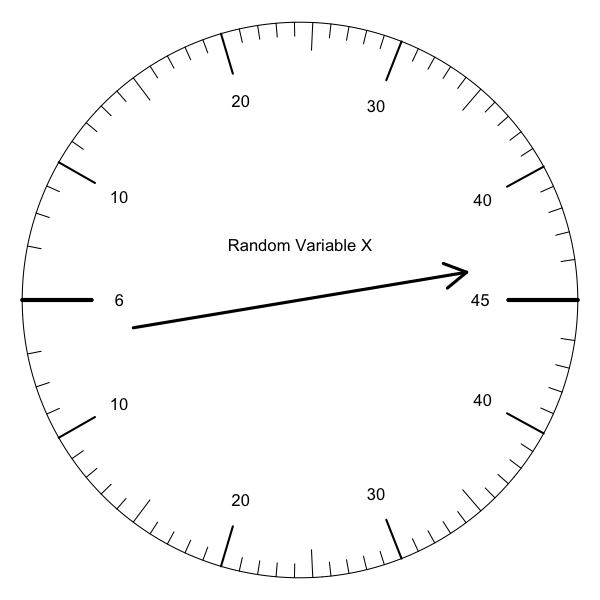

   That spinner ($X$) will be fairly spun 675 times, and the **sample mean** ($\bar{X}$) of the spins will be recorded. Determine the probability that the random sample mean is more than 25.64.
   $$P\left(\bar{X}>25.64\right) ~=~ \,?$$

   (Even though single spins are **not** normally distributed, the random means will be normally distributed. See [central limit theorem](https://en.wikipedia.org/wiki/Central_limit_theorem).)

#### Question

7. The continuous random variable $X$ follows the distribution shown by the density curve and spinner below. It has a mean of $\mu=67.38$ and standard deviation of $\sigma=13.22$.

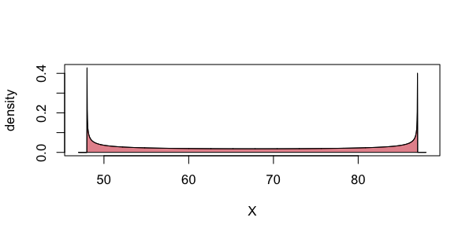

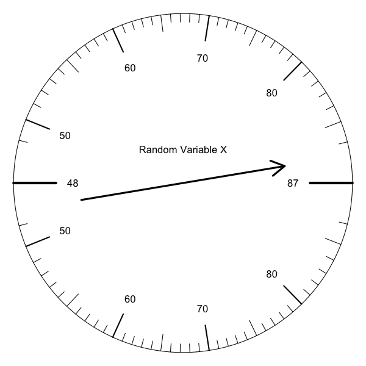

   That spinner ($X$) will be fairly spun 379 times, and the **sample mean** ($\bar{X}$) of the spins will be recorded. Determine the probability that the random sample mean is more than 67.38.
   $$P\left(\bar{X}>67.38\right) ~=~ \,?$$

   (Even though single spins are **not** normally distributed, the random means will be normally distributed. See [central limit theorem](https://en.wikipedia.org/wiki/Central_limit_theorem).)

#### Question

8. The continuous random variable $X$ follows the distribution shown by the density curve and spinner below. It has a mean of $\mu=20.66$ and standard deviation of $\sigma=5.92$.

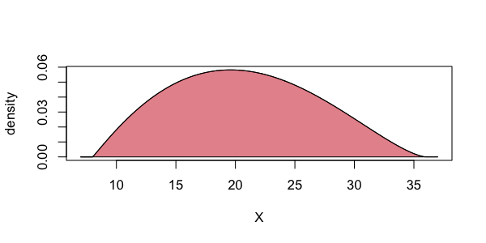

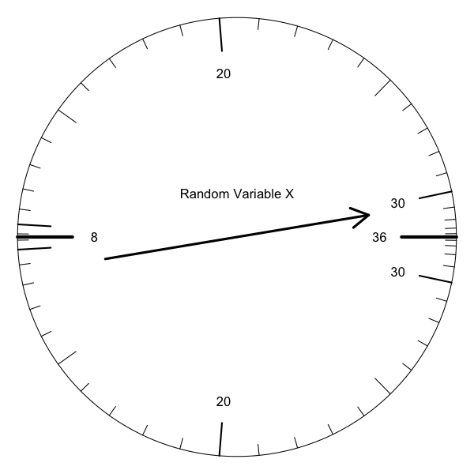

   That spinner ($X$) will be fairly spun 326 times, and the **sample mean** ($\bar{X}$) of the spins will be recorded. Determine the probability that the random sample mean is more than 20.75.
   $$P\left(\bar{X}>20.75\right) ~=~ \,?$$

   (Even though single spins are **not** normally distributed, the random means will be normally distributed. See [central limit theorem](https://en.wikipedia.org/wiki/Central_limit_theorem).)